# Module 74

#### Hemi-module gene counts:

392 probesets in hemi-module A.  
13 probesets in hemi-module B.  
Note: While the mapping of probesets to genes is usually one-to-one, some genes are targeted by multiple probesets, some probesets target multiple genes, and some probesets do not target any genes (i.e., the region of the genome they match is no longer considered genic).

#### Contrast SVE:

Signed variance explained (SVE) provides an indication of how similar a set of fold changes are to a gene module’s weight vector. An SVE value of 0.3, for example, indicates that 30% of the variance explained by the entire module set is accounted for by the module in question. Shown here are the SVE values for this module across a compendium of fold changes (contrasts). Extreme SVE values (e.g., > 0.05) indicate that those contrasts specifically induce (orange dots) or specifically repress (blue dots) this module. Examining the experimental conditions being compared in such contrasts (see tables below the figure) may provide insight into the gene module’s function.

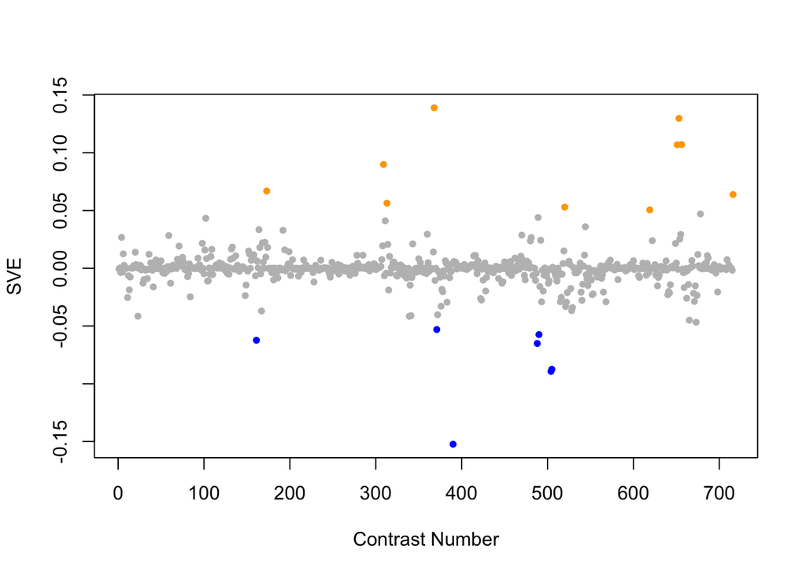

Positive SVE Contrasts:

|  | Contrast.Num | SVE | GEO.GSE | Cond.1 | Cond.2 | Mutation |
| --- | --- | --- | --- | --- | --- | --- |
| GSE35360A.s2t1.vs.s0t1 | 368 | 0.14 | GSE35360 | HF 11d_2.0_rep1 | HF 11d control_rep1 |  |
| GSE16405.s4t1.vs.s2t1 | 653 | 0.13 | GSE16405 | xpa-1_1 | nth-1_1 | nth-1 vs. xpa-1 |
| GSE16050.s1t1.vs.s0t1 | 656 | 0.11 | GSE16050 | MT_GFPp_rep1 | WT_GFPp_rep1 |  |
| GSE16405.s4t1.vs.s1t1 | 651 | 0.11 | GSE16405 | xpa-1_1 | N2_1 | xpa-1 |
| GSE41056.s2t1.vs.s0t1 | 309 | 0.09 | GSE41056 | RDE_1_1 | N2_1 | rde-1 |
| GSE47778.s1t3.vs.s4t3 | 173 | 0.07 | GSE47778 | N2; UV; replicate 1 | daf-2;daf-16; UV; replicate 1 | daf-2;daf-16 |
| GSE10787B.s1t1.vs.s0t1 | 716 | 0.06 | GSE10787 | Microwave (de_Pomerai_10_E5_C.Elegans) | Sham (de_Pomerai_1_S1_C.Elegans) |  |
| GSE41056.s0t2.vs.s0t1 | 313 | 0.06 | GSE41056 | N2_inf_1 | N2_1 |  |
| GSE2180.s4t7.vs.s3t7 | 520 | 0.05 | GSE2180 | pp101-1 | p101-2 | pal-1(RNAi) |
| GSE21467.s1t1.vs.s0t1 | 619 | 0.05 | GSE21467 | ung-1, biological rep1 | wild type N2, biological rep1 | ung-1 |

Negative SVE Contrasts:

|  | Contrast.Num | SVE | GEO.GSE | Cond.1 | Cond.2 | Mutation |
| --- | --- | --- | --- | --- | --- | --- |
| GSE32521.s1t1.vs.s0t1 | 390 | -0.15 | GSE32521 | Au-NP Replicate1 | Control Replicate1 |  |
| GSE22660.s0t2.vs.s0t1 | 504 | -0.09 | GSE22660 | 1ug/ml DMSO control, biological rep 1 | 100ng/ml DMSO control, biological rep 1 |  |
| GSE22660.s1t2.vs.s1t1 | 505 | -0.09 | GSE22660 | 1ug/ml ivermectin exposure, biological rep 1 | 100ng/ml ivermectin exposure, biological rep 1 |  |
| GSE23528B.s1t2.vs.s1t1 | 488 | -0.07 | GSE23528 | Adult at T30 in CC, time-series experiment 3 | Adult at T26 in CC, time-series experiment 3 |  |
| GSE47778.s4t2.vs.s3t2 | 161 | -0.06 | GSE47778 | daf-2;daf-16; starvation; replicate 1 | daf-16; starvation; replicate 1 | daf-2;daf-16 vs. daf-16 |
| GSE23528B.s1t4.vs.s1t1 | 490 | -0.06 | GSE23528 | Adult at T38 in CC, time-series experiment 3 | Adult at T26 in CC, time-series experiment 3 |  |
| GSE35360C.s1t1.vs.s0t1 | 371 | -0.05 | GSE35360 | HFHQ 3d_0.2_rep1 | HFHQ 3d control_rep1 |  |

$~$

#### Contrast SVE, Up-Regulated Genes Only:

Calculating SVE for up-regulated and down-regulated genes separately may be more informative in many cases than projecting the up- and down- gene sets together. This is due to the fact that the weight distribution of many modules is highly skewed, indicating that only one of the hemi-modules may be biologically meaningful (i.e., a set of genes are strongly correlated by only a few genes (or none) are strongly anti-correlated to that set.)

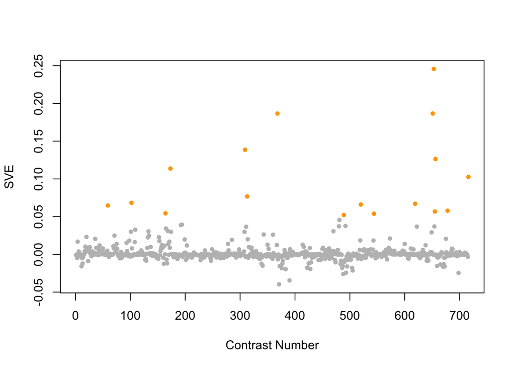

Positive SVE Contrasts:

|  | Contrast.Num | SVE | GEO.GSE | Cond.1 | Cond.2 | Mutation |
| --- | --- | --- | --- | --- | --- | --- |
| GSE16405.s4t1.vs.s2t1 | 653 | 0.25 | GSE16405 | xpa-1_1 | nth-1_1 | nth-1 vs. xpa-1 |
| GSE16405.s4t1.vs.s1t1 | 651 | 0.19 | GSE16405 | xpa-1_1 | N2_1 | xpa-1 |
| GSE35360A.s2t1.vs.s0t1 | 368 | 0.19 | GSE35360 | HF 11d_2.0_rep1 | HF 11d control_rep1 |  |
| GSE41056.s2t1.vs.s0t1 | 309 | 0.14 | GSE41056 | RDE_1_1 | N2_1 | rde-1 |
| GSE16050.s1t1.vs.s0t1 | 656 | 0.13 | GSE16050 | MT_GFPp_rep1 | WT_GFPp_rep1 |  |
| GSE47778.s1t3.vs.s4t3 | 173 | 0.11 | GSE47778 | N2; UV; replicate 1 | daf-2;daf-16; UV; replicate 1 | daf-2;daf-16 |
| GSE10787B.s1t1.vs.s0t1 | 716 | 0.10 | GSE10787 | Microwave (de_Pomerai_10_E5_C.Elegans) | Sham (de_Pomerai_1_S1_C.Elegans) |  |
| GSE41056.s0t2.vs.s0t1 | 313 | 0.08 | GSE41056 | N2_inf_1 | N2_1 |  |
| GSE5793.s2t2.vs.s2t1 | 102 | 0.07 | GSE5793 | Celegans_OP50_8hours_RepA | Celegans_OP50_4hours_RepA |  |
| GSE21467.s1t1.vs.s0t1 | 619 | 0.07 | GSE21467 | ung-1, biological rep1 | wild type N2, biological rep1 | ung-1 |
| GSE2180.s4t7.vs.s3t7 | 520 | 0.07 | GSE2180 | pp101-1 | p101-2 | pal-1(RNAi) |
| GSE9301.s2t1.vs.s1t1 | 59 | 0.06 | GSE9301 | 3-day-old TJ1090 worms with skn-1 RNAi & oxidative stress (SO1) | 3-day-old TJ1090 worms with oxidative stress (O1) | skn-1 |
| GSE13258.s1t1.vs.s0t1 | 678 | 0.06 | GSE13258 | zfp-1 mutant, biological rep 1 | wild-type, biological rep 1 | zfp-1 |
| GSE16050.s1t2.vs.s0t2 | 655 | 0.06 | GSE16050 | MT_GFPm_rep1 | WT_GFPm_rep1 |  |
| GSE47778.s1t2.vs.s2t2 | 164 | 0.05 | GSE47778 | N2; starvation; replicate 1 | daf-2; starvation; replicate 1 | daf-2 |
| GSE2180.s4t2.vs.s3t2 | 544 | 0.05 | GSE2180 | pp23-1 | p23-2 | pal-1(RNAi) |
| GSE23528B.s1t3.vs.s1t1 | 489 | 0.05 | GSE23528 | Adult at T34 in CC, time-series experiment 3 | Adult at T26 in CC, time-series experiment 3 |  |

Negative SVE Contrasts:

|  | Contrast.Num | SVE | GEO.GSE | Cond.1 | Cond.2 | Mutation |
| --- | --- | --- | --- | --- | --- | --- |
| GSE35360C.s1t1.vs.s0t1 | 371 | -0.04 | GSE35360 | HFHQ 3d_0.2_rep1 | HFHQ 3d control_rep1 |  |
| GSE32521.s1t1.vs.s0t1 | 390 | -0.03 | GSE32521 | Au-NP Replicate1 | Control Replicate1 |  |
| GSE23528B.s1t2.vs.s1t1 | 488 | -0.03 | GSE23528 | Adult at T30 in CC, time-series experiment 3 | Adult at T26 in CC, time-series experiment 3 |  |
| GSE11055.s3t4.vs.s2t4 | 698 | -0.02 | GSE11055 | L1 larvae 3 hr after hatching in the absence of food in the alternative starvation buffer M9 | L1 larvae 3 hr after hatching in the absence of food |  |
| GSE23528C.s1t2.vs.s1t1 | 493 | -0.02 | GSE23528 | Adult at T30 in DD, time-series experiment 2 | Adult at T26 in DD, time-series experiment 2 |  |

$~$

#### Contrast SVE, Down-Regulated Genes Only:

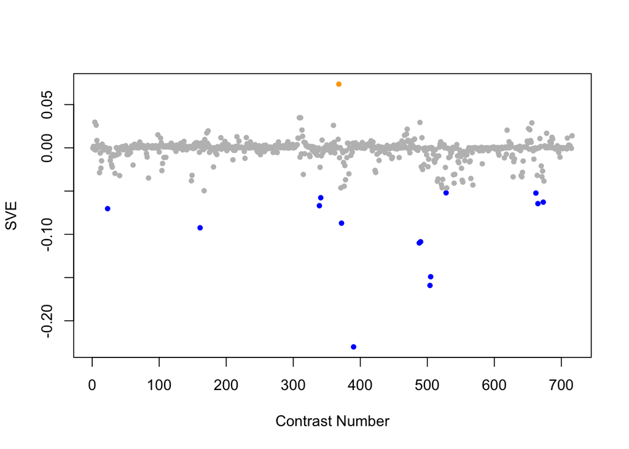

Positive SVE Contrasts:

|  | Contrast.Num | SVE | GEO.GSE | Cond.1 | Cond.2 | Mutation |
| --- | --- | --- | --- | --- | --- | --- |
| GSE35360A.s2t1.vs.s0t1 | 368 | 0.07 | GSE35360 | HF 11d_2.0_rep1 | HF 11d control_rep1 |  |
| GSE41056.s2t1.vs.s0t1 | 309 | 0.03 | GSE41056 | RDE_1_1 | N2_1 | rde-1 |
| GSE41056.s2t2.vs.s0t2 | 311 | 0.03 | GSE41056 | RDE_1_inf_1 | N2_inf_1 | rde-1 |
| GSE9897B.s1t1.vs.s0t1 | 4 | 0.03 | GSE9897 | Complex I RNAi Mutant 1 | Wildtype (control for RNAi) | F22D6.4 |
| GSE23528B.s1t3.vs.s1t1 | 489 | 0.03 | GSE23528 | Adult at T34 in CC, time-series experiment 3 | Adult at T26 in CC, time-series experiment 3 |  |

Negative SVE Contrasts:

|  | Contrast.Num | SVE | GEO.GSE | Cond.1 | Cond.2 | Mutation |
| --- | --- | --- | --- | --- | --- | --- |
| GSE32521.s1t1.vs.s0t1 | 390 | -0.23 | GSE32521 | Au-NP Replicate1 | Control Replicate1 |  |
| GSE22660.s0t2.vs.s0t1 | 504 | -0.16 | GSE22660 | 1ug/ml DMSO control, biological rep 1 | 100ng/ml DMSO control, biological rep 1 |  |
| GSE22660.s1t2.vs.s1t1 | 505 | -0.15 | GSE22660 | 1ug/ml ivermectin exposure, biological rep 1 | 100ng/ml ivermectin exposure, biological rep 1 |  |
| GSE23528B.s1t2.vs.s1t1 | 488 | -0.11 | GSE23528 | Adult at T30 in CC, time-series experiment 3 | Adult at T26 in CC, time-series experiment 3 |  |
| GSE23528B.s1t4.vs.s1t1 | 490 | -0.11 | GSE23528 | Adult at T38 in CC, time-series experiment 3 | Adult at T26 in CC, time-series experiment 3 |  |
| GSE47778.s4t2.vs.s3t2 | 161 | -0.09 | GSE47778 | daf-2;daf-16; starvation; replicate 1 | daf-16; starvation; replicate 1 | daf-2;daf-16 vs. daf-16 |
| GSE35360C.s2t1.vs.s0t1 | 372 | -0.09 | GSE35360 | HFHQ 3d_2.0_rep1 | HFHQ 3d control_rep1 |  |
| GSE9665.s2t2.vs.s0t2 | 23 | -0.07 | GSE9665 | mex-3 elt-3 186 A | mex-3 186 A | elt-3 |
| GSE38997.s3t1.vs.s1t1 | 339 | -0.07 | GSE38997 | experiment 4 UVC- and EtBr-exposed samples at 3 h 4eu3 | experiment 4 control samples at 3 h 4c3 |  |
| GSE15159.s1t2.vs.s1t1 | 665 | -0.06 | GSE15159 | glp-1_UV_2007_rep1 | glp-1_control_2007_rep1 |  |
| GSE14640B.s1t1.vs.s0t1 | 673 | -0.06 | GSE14640 | XX_DPY27-N_042807_A | XX_WT-N_080307_A |  |
| GSE38997.s3t1.vs.s2t1 | 341 | -0.06 | GSE38997 | experiment 4 UVC- and EtBr-exposed samples at 3 h 4eu3 | experiment 4 EtBr-exposed samples at 3 h 4e3 |  |
| GSE15159.s2t1.vs.s0t1 | 662 | -0.05 | GSE15159 | xpa-1_control_2007_rep1 | N2_control_2007_rep1 | xpa-1 |
| GSE2180.s3t9.vs.s1t9 | 528 | -0.05 | GSE2180 | p143-2 | 143L | pie-1(zu154) |

$~$

$~$

#### GO Term Enrichment:

This analysis tests each hemi-module for enrichment of specific GO terms. Only gene-level annotations (e.g., as would be found on the gene’s page in Wormbase) are tested - the hierarchical structure of the GO ontology is not taken into account.

*Note: At least the top two most enriched terms from each GO domain (BP/MF/CC) are shown, even when not statistically significant.*

##### Enriched GO terms: Hemi-module A

| ID | GO.Term | GO Domain | Raw p-value | Adj p-value |
| --- | --- | --- | --- | --- |
| [GO_0009792](http://amigo.geneontology.org/amigo/term/GO:0009792) | embryo development ending in birth or egg hatching | BP | 1.87e-18 | 6.81e-15 |
| [GO_0010172](http://amigo.geneontology.org/amigo/term/GO:0010172) | embryonic body morphogenesis | BP | 3.32e-11 | 6.04e-08 |
| [GO_0002119](http://amigo.geneontology.org/amigo/term/GO:0002119) | nematode larval development | BP | 5.23e-09 | 5.66e-06 |
| [GO_0006997](http://amigo.geneontology.org/amigo/term/GO:0006997) | nucleus organization | BP | 6.21e-09 | 5.66e-06 |
| [GO_0006417](http://amigo.geneontology.org/amigo/term/GO:0006417) | regulation of translation | BP | 2.53e-08 | 1.85e-05 |
| [GO_0043547](http://amigo.geneontology.org/amigo/term/GO:0043547) | positive regulation of GTPase activity | BP | 5.11e-07 | 3.10e-04 |
| [GO_0007275](http://amigo.geneontology.org/amigo/term/GO:0007275) | multicellular organism development | BP | 2.95e-06 | 1.54e-03 |
| [GO_0006897](http://amigo.geneontology.org/amigo/term/GO:0006897) | endocytosis | BP | 5.83e-06 | 2.65e-03 |
| [GO_0008104](http://amigo.geneontology.org/amigo/term/GO:0008104) | protein localization | BP | 7.91e-06 | 3.20e-03 |
| [GO_0031929](http://amigo.geneontology.org/amigo/term/GO:0031929) | TOR signaling | BP | 1.09e-05 | 3.62e-03 |
| [GO_0051661](http://amigo.geneontology.org/amigo/term/GO:0051661) | maintenance of centrosome location | BP | 1.09e-05 | 3.62e-03 |
| [GO_0040027](http://amigo.geneontology.org/amigo/term/GO:0040027) | negative regulation of vulval development | BP | 2.01e-05 | 5.78e-03 |
| [GO_0051301](http://amigo.geneontology.org/amigo/term/GO:0051301) | cell division | BP | 2.06e-05 | 5.78e-03 |
| [GO_0007049](http://amigo.geneontology.org/amigo/term/GO:0007049) | cell cycle | BP | 3.68e-05 | 9.59e-03 |
| [GO_0007186](http://amigo.geneontology.org/amigo/term/GO:0007186) | G protein-coupled receptor signaling pathway | BP | 6.05e-05 | 1.33e-02 |
| [GO_0030866](http://amigo.geneontology.org/amigo/term/GO:0030866) | cortical actin cytoskeleton organization | BP | 6.19e-05 | 1.33e-02 |
| [GO_0030953](http://amigo.geneontology.org/amigo/term/GO:0030953) | astral microtubule organization | BP | 6.19e-05 | 1.33e-02 |
| [GO_0030334](http://amigo.geneontology.org/amigo/term/GO:0030334) | regulation of cell migration | BP | 7.89e-05 | 1.50e-02 |
| [GO_0006606](http://amigo.geneontology.org/amigo/term/GO:0006606) | protein import into nucleus | BP | 8.25e-05 | 1.50e-02 |
| [GO_0016579](http://amigo.geneontology.org/amigo/term/GO:0016579) | protein deubiquitination | BP | 8.25e-05 | 1.50e-02 |
| [GO_0015031](http://amigo.geneontology.org/amigo/term/GO:0015031) | protein transport | BP | 1.08e-04 | 1.88e-02 |
| [GO_0045807](http://amigo.geneontology.org/amigo/term/GO:0045807) | positive regulation of endocytosis | BP | 1.34e-04 | 2.12e-02 |
| [GO_0061404](http://amigo.geneontology.org/amigo/term/GO:0061404) | positive regulation of transcription from RNA polymerase II promoter in response to increased salt | BP | 1.34e-04 | 2.12e-02 |
| [GO_0010468](http://amigo.geneontology.org/amigo/term/GO:0010468) | regulation of gene expression | BP | 1.42e-04 | 2.15e-02 |
| [GO_0051321](http://amigo.geneontology.org/amigo/term/GO:0051321) | meiotic cell cycle | BP | 1.57e-04 | 2.29e-02 |
| [GO_0016310](http://amigo.geneontology.org/amigo/term/GO:0016310) | phosphorylation | BP | 1.92e-04 | 2.66e-02 |
| [GO_0060465](http://amigo.geneontology.org/amigo/term/GO:0060465) | pharynx development | BP | 1.97e-04 | 2.66e-02 |
| [GO_0042176](http://amigo.geneontology.org/amigo/term/GO:0042176) | regulation of protein catabolic process | BP | 2.63e-04 | 3.19e-02 |
| [GO_0055064](http://amigo.geneontology.org/amigo/term/GO:0055064) | chloride ion homeostasis | BP | 2.63e-04 | 3.19e-02 |
| [GO_0055075](http://amigo.geneontology.org/amigo/term/GO:0055075) | potassium ion homeostasis | BP | 2.63e-04 | 3.19e-02 |

[output cut: 83 more lines]

##### Enriched GO terms: Hemi-module B

| ID | GO.Term | GO Domain | Raw p-value | Adj p-value |
| --- | --- | --- | --- | --- |
| [GO_0042004](http://amigo.geneontology.org/amigo/term/GO:0042004) | feminization of hermaphrodite soma | BP | 8.31e-04 | 1.00e+00 |
| [GO_0006513](http://amigo.geneontology.org/amigo/term/GO:0006513) | protein monoubiquitination | BP | 1.66e-03 | 1.00e+00 |
| [GO_0004647](http://amigo.geneontology.org/amigo/term/GO:0004647) | phosphoserine phosphatase activity | MF | 8.31e-04 | 1.00e+00 |
| [GO_0017099](http://amigo.geneontology.org/amigo/term/GO:0017099) | very-long-chain-acyl-CoA dehydrogenase activity | MF | 1.66e-03 | 1.00e+00 |
| [GO_0016593](http://amigo.geneontology.org/amigo/term/GO:0016593) | Cdc73/Paf1 complex | CC | 4.98e-03 | 1.00e+00 |
| [GO_0017119](http://amigo.geneontology.org/amigo/term/GO:0017119) | Golgi transport complex | CC | 5.80e-03 | 1.00e+00 |

$~$

$~$

#### Tissue Enrichment:

This analysis tests each hemi-module for enrichment of genes associated with anatomy terms. Negative enrichment scores indicate fewer hemi-module genes than expected by random chance were associated with the anatomy term in question.

##### Enriched tissues: Hemi-module A

| ID | Anatomy.Term | Definition | Raw p-value | Adj p-value |
| --- | --- | --- | --- | --- |
| [WBbt_0004017](https://wormbase.org/species/all/anatomy_term/WBbt:0004017) | Cell | a cellular object that consists of subcellular components, expresses genes or functions. | 6.19e-09 | 1.51e-05 |
| [WBbt_0003681](https://wormbase.org/species/all/anatomy_term/WBbt:0003681) | pharynx | the feeding organ, a neuro-muscular pump in the head of the animal, used to ingest food, bacteria suspended in liquid, filter them out, grind them up and transport posteriorly into the instestine. | 9.07e-07 | 1.10e-03 |
| [WBbt_0005813](https://wormbase.org/species/all/anatomy_term/WBbt:0005813) | body wall musculature | Longitudinal bands of muscle cells surrounding animal body, with one band running in each quadrant of the body, regulated contraction and relaxation of these muscles cause locomotion. | 1.40e-06 | 1.14e-03 |
| [WBbt_0005753](https://wormbase.org/species/all/anatomy_term/WBbt:0005753) | seam cell | a group of hypodermal cells that lie along the apical midline of the hypodermis, at the extreme left and right sides between nose and tail | 1.37e-05 | 8.31e-03 |
| [WBbt_0005733](https://wormbase.org/species/all/anatomy_term/WBbt:0005733) | hypodermis | Epidermal layer. | 4.27e-05 | 2.08e-02 |
| [WBbt_0006028](https://wormbase.org/species/all/anatomy_term/WBbt:0006028) | ABplppap | embryonic cell | 9.51e-05 | 2.47e-02 |
| [WBbt_0006470](https://wormbase.org/species/all/anatomy_term/WBbt:0006470) | ABplappp | embryonic cell | 9.51e-05 | 2.47e-02 |
| [WBbt_0007846](https://wormbase.org/species/all/anatomy_term/WBbt:0007846) | hypodermal cell | primary cell type that forms the hypodermis. | 1.07e-04 | 2.47e-02 |
| [WBbt_0005772](https://wormbase.org/species/all/anatomy_term/WBbt:0005772) | intestine | A chain of very large cuboidal cells forming a wide central lumen in which food arrives from the posterior pharynx, is digested, and from which waste products proceed to the rectum. Intestinal rings f… | 1.20e-04 | 2.47e-02 |
| [WBbt_0006095](https://wormbase.org/species/all/anatomy_term/WBbt:0006095) | ABplappa | embryonic cell | 1.32e-04 | 2.47e-02 |
| [WBbt_0006478](https://wormbase.org/species/all/anatomy_term/WBbt:0006478) | ABplaaap | embryonic cell | 1.32e-04 | 2.47e-02 |
| [WBbt_0006584](https://wormbase.org/species/all/anatomy_term/WBbt:0006584) | ABplaaaa | embryonic cell | 1.32e-04 | 2.47e-02 |
| [WBbt_0006619](https://wormbase.org/species/all/anatomy_term/WBbt:0006619) | ABplaapa | embryonic cell | 1.32e-04 | 2.47e-02 |
| [WBbt_0005784](https://wormbase.org/species/all/anatomy_term/WBbt:0005784) | germ line | cell line which early in development becomes differentiated from the remaining somatic cell line, and alone has the potential to undergo meiosis and form gametes. | 1.66e-04 | 2.88e-02 |
| [WBbt_0006534](https://wormbase.org/species/all/anatomy_term/WBbt:0006534) | ABpraaap | embryonic cell | 2.04e-04 | 3.05e-02 |
| [WBbt_0006730](https://wormbase.org/species/all/anatomy_term/WBbt:0006730) | ABplapaa | embryonic cell | 2.04e-04 | 3.05e-02 |
| [WBbt_0006546](https://wormbase.org/species/all/anatomy_term/WBbt:0006546) | Ealp | embryonic cell | 2.38e-04 | 3.05e-02 |
| [WBbt_0005861](https://wormbase.org/species/all/anatomy_term/WBbt:0005861) | ABaraaap | embryonic cell | 2.51e-04 | 3.05e-02 |
| [WBbt_0006259](https://wormbase.org/species/all/anatomy_term/WBbt:0006259) | ABprpapa | embryonic cell | 2.51e-04 | 3.05e-02 |
| [WBbt_0006335](https://wormbase.org/species/all/anatomy_term/WBbt:0006335) | ABpraapp | embryonic cell | 2.51e-04 | 3.05e-02 |
| [WBbt_0006420](https://wormbase.org/species/all/anatomy_term/WBbt:0006420) | ABplpapp | embryonic cell | 3.05e-04 | 3.37e-02 |
| [WBbt_0006524](https://wormbase.org/species/all/anatomy_term/WBbt:0006524) | ABarappp | embryonic cell | 3.05e-04 | 3.37e-02 |
| [WBbt_0005853](https://wormbase.org/species/all/anatomy_term/WBbt:0005853) | ABaraapa | embryonic cell | 3.69e-04 | 3.89e-02 |
| [WBbt_0005319](https://wormbase.org/species/all/anatomy_term/WBbt:0005319) | spermatheca | an accordion-like tube that contains sperm and is the site of oocyte fertilization. | 3.84e-04 | 3.89e-02 |
| [WBbt_0005984](https://wormbase.org/species/all/anatomy_term/WBbt:0005984) | ABprppaa | embryonic cell | 4.43e-04 | 3.98e-02 |
| [WBbt_0006153](https://wormbase.org/species/all/anatomy_term/WBbt:0006153) | ABaraapp | embryonic cell | 4.43e-04 | 3.98e-02 |
| [WBbt_0006360](https://wormbase.org/species/all/anatomy_term/WBbt:0006360) | ABaraaaa | embryonic cell | 4.43e-04 | 3.98e-02 |
| [WBbt_0006269](https://wormbase.org/species/all/anatomy_term/WBbt:0006269) | ABprappa | embryonic cell | 5.28e-04 | 3.98e-02 |
| [WBbt_0006346](https://wormbase.org/species/all/anatomy_term/WBbt:0006346) | ABprppap | embryonic cell | 5.28e-04 | 3.98e-02 |
| [WBbt_0006515](https://wormbase.org/species/all/anatomy_term/WBbt:0006515) | ABarapaa | embryonic cell | 5.28e-04 | 3.98e-02 |

[output cut: 53 more lines]

##### Enriched tissues: Hemi-module B

No significant annotations.

$~$

$~$

#### HOMER promoter motif enrichment:

This analysis tests each hemi-module for enrichment of 108 known *C. elegans* transcription factor binding site motifs (see [108 CE motifs](https://katiepod.github.io//all.worm.motifs.html)) using the HOMER (Hypergeometric Optimization of Motif EnRichment) software (see [PMID:20513432](https://pubmed.ncbi.nlm.nih.gov/20513432)). HOMER was run using default parameters on sequences 1 kb upstream of the transcription start site.

##### Motif enrichment: Hemi-module A

Total target sequences = 318  
Total background sequences = 35833  
* - possible false positive

Rank

Motif

P-value

log P-pvalue

% of Targets

% of Background

STD(Bg STD)

Best Match/Details

Motif File

1

[figure not shown]

1e-13

-3.172e+01

61.64%

40.26%

266.6bp (377.1bp)

DPL-1(E2F)/cElegans-Adult-ChIP-Seq(modEncode)/Homer(0.791)  
[More Information](https://katiepod.github.io/HomerResults/m74_a_hemi_genes.txt.out.1kb/homerResults/motif1.info.html) | [Similar Motifs Found](https://katiepod.github.io/HomerResults/m74_a_hemi_genes.txt.out.1kb/homerResults/motif1.similar.html)

[motif file (matrix)](https://katiepod.github.io/HomerResults/m74_a_hemi_genes.txt.out.1kb/homerResults/motif1.motif)

2

[figure not shown]

1e-12

-2.957e+01

16.98%

5.39%

254.8bp (346.6bp)

POL007.1_BREd/Jaspar(0.531)  
[More Information](https://katiepod.github.io/HomerResults/m74_a_hemi_genes.txt.out.1kb/homerResults/motif2.info.html) | [Similar Motifs Found](https://katiepod.github.io/HomerResults/m74_a_hemi_genes.txt.out.1kb/homerResults/motif2.similar.html)

[motif file (matrix)](https://katiepod.github.io/HomerResults/m74_a_hemi_genes.txt.out.1kb/homerResults/motif2.motif)

3

[figure not shown]

1e-12

-2.864e+01

3.14%

0.07%

314.4bp (311.5bp)

pal-1/MA0924.1/Jaspar(0.620)  
[More Information](https://katiepod.github.io/HomerResults/m74_a_hemi_genes.txt.out.1kb/homerResults/motif3.info.html) | [Similar Motifs Found](https://katiepod.github.io/HomerResults/m74_a_hemi_genes.txt.out.1kb/homerResults/motif3.similar.html)

[motif file (matrix)](https://katiepod.github.io/HomerResults/m74_a_hemi_genes.txt.out.1kb/homerResults/motif3.motif)

4

[figure not shown]

1e-12

-2.842e+01

7.86%

1.20%

275.5bp (352.3bp)

lin-14/MA0261.1/Jaspar(0.584)  
[More Information](https://katiepod.github.io/HomerResults/m74_a_hemi_genes.txt.out.1kb/homerResults/motif4.info.html) | [Similar Motifs Found](https://katiepod.github.io/HomerResults/m74_a_hemi_genes.txt.out.1kb/homerResults/motif4.similar.html)

[motif file (matrix)](https://katiepod.github.io/HomerResults/m74_a_hemi_genes.txt.out.1kb/homerResults/motif4.motif)

5 *

[figure not shown]

1e-11

-2.729e+01

22.64%

9.27%

270.3bp (354.0bp)

eor-1/MA0543.1/Jaspar(0.798)  
[More Information](https://katiepod.github.io/HomerResults/m74_a_hemi_genes.txt.out.1kb/homerResults/motif5.info.html) | [Similar Motifs Found](https://katiepod.github.io/HomerResults/m74_a_hemi_genes.txt.out.1kb/homerResults/motif5.similar.html)

[motif file (matrix)](https://katiepod.github.io/HomerResults/m74_a_hemi_genes.txt.out.1kb/homerResults/motif5.motif)

6 *

[figure not shown]

1e-11

-2.570e+01

44.97%

27.03%

293.0bp (365.4bp)

fkh-9/MA1440.1/Jaspar(0.597)  
[More Information](https://katiepod.github.io/HomerResults/m74_a_hemi_genes.txt.out.1kb/homerResults/motif6.info.html) | [Similar Motifs Found](https://katiepod.github.io/HomerResults/m74_a_hemi_genes.txt.out.1kb/homerResults/motif6.similar.html)

[motif file (matrix)](https://katiepod.github.io/HomerResults/m74_a_hemi_genes.txt.out.1kb/homerResults/motif6.motif)

7 *

[figure not shown]

1e-11

-2.555e+01

25.47%

11.59%

268.8bp (356.8bp)

cebp-1/MA1444.1/Jaspar(0.815)  
[More Information](https://katiepod.github.io/HomerResults/m74_a_hemi_genes.txt.out.1kb/homerResults/motif7.info.html) | [Similar Motifs Found](https://katiepod.github.io/HomerResults/m74_a_hemi_genes.txt.out.1kb/homerResults/motif7.similar.html)

[motif file (matrix)](https://katiepod.github.io/HomerResults/m74_a_hemi_genes.txt.out.1kb/homerResults/motif7.motif)

8 *

[figure not shown]

1e-10

-2.513e+01

2.83%

0.07%

349.3bp (337.4bp)

dpy-27/MA0540.1/Jaspar(0.544)  
[More Information](https://katiepod.github.io/HomerResults/m74_a_hemi_genes.txt.out.1kb/homerResults/motif8.info.html) | [Similar Motifs Found](https://katiepod.github.io/HomerResults/m74_a_hemi_genes.txt.out.1kb/homerResults/motif8.similar.html)

[motif file (matrix)](https://katiepod.github.io/HomerResults/m74_a_hemi_genes.txt.out.1kb/homerResults/motif8.motif)

9 *

[figure not shown]

1e-10

-2.510e+01

11.32%

2.94%

288.2bp (369.3bp)

LIN-15B(Zf)/cElegans-L3-LIN15B-ChIP-Seq(modEncode)/Homer(0.747)  
[More Information](https://katiepod.github.io/HomerResults/m74_a_hemi_genes.txt.out.1kb/homerResults/motif9.info.html) | [Similar Motifs Found](https://katiepod.github.io/HomerResults/m74_a_hemi_genes.txt.out.1kb/homerResults/motif9.similar.html)

[motif file (matrix)](https://katiepod.github.io/HomerResults/m74_a_hemi_genes.txt.out.1kb/homerResults/motif9.motif)

10 *

[figure not shown]

1e-10

-2.491e+01

41.19%

24.06%

290.1bp (394.8bp)

ceh-38/MA1699.1/Jaspar(0.897)  
[More Information](https://katiepod.github.io/HomerResults/m74_a_hemi_genes.txt.out.1kb/homerResults/motif10.info.html) | [Similar Motifs Found](https://katiepod.github.io/HomerResults/m74_a_hemi_genes.txt.out.1kb/homerResults/motif10.similar.html)

[motif file (matrix)](https://katiepod.github.io/HomerResults/m74_a_hemi_genes.txt.out.1kb/homerResults/motif10.motif)

11 *

[figure not shown]

1e-10

-2.456e+01

4.72%

0.42%

304.8bp (399.6bp)

blmp-1/MA0537.1/Jaspar(0.577)  
[More Information](https://katiepod.github.io/HomerResults/m74_a_hemi_genes.txt.out.1kb/homerResults/motif11.info.html) | [Similar Motifs Found](https://katiepod.github.io/HomerResults/m74_a_hemi_genes.txt.out.1kb/homerResults/motif11.similar.html)

[motif file (matrix)](https://katiepod.github.io/HomerResults/m74_a_hemi_genes.txt.out.1kb/homerResults/motif11.motif)

12 *

[figure not shown]

1e-10

-2.352e+01

2.83%

0.09%

255.7bp (389.8bp)

PL0007.1_mxl-3/Jaspar(0.632)  
[More Information](https://katiepod.github.io/HomerResults/m74_a_hemi_genes.txt.out.1kb/homerResults/motif12.info.html) | [Similar Motifs Found](https://katiepod.github.io/HomerResults/m74_a_hemi_genes.txt.out.1kb/homerResults/motif12.similar.html)

[motif file (matrix)](https://katiepod.github.io/HomerResults/m74_a_hemi_genes.txt.out.1kb/homerResults/motif12.motif)

13 *

[figure not shown]

1e-10

-2.311e+01

20.75%

8.87%

270.6bp (351.5bp)

eor-1/MA0543.1/Jaspar(0.662)  
[More Information](https://katiepod.github.io/HomerResults/m74_a_hemi_genes.txt.out.1kb/homerResults/motif13.info.html) | [Similar Motifs Found](https://katiepod.github.io/HomerResults/m74_a_hemi_genes.txt.out.1kb/homerResults/motif13.similar.html)

[motif file (matrix)](https://katiepod.github.io/HomerResults/m74_a_hemi_genes.txt.out.1kb/homerResults/motif13.motif)

14 *

[figure not shown]

1e-10

-2.309e+01

21.70%

9.51%

261.7bp (338.3bp)

fkh-9/MA1440.1/Jaspar(0.726)  
[More Information](https://katiepod.github.io/HomerResults/m74_a_hemi_genes.txt.out.1kb/homerResults/motif14.info.html) | [Similar Motifs Found](https://katiepod.github.io/HomerResults/m74_a_hemi_genes.txt.out.1kb/homerResults/motif14.similar.html)

[motif file (matrix)](https://katiepod.github.io/HomerResults/m74_a_hemi_genes.txt.out.1kb/homerResults/motif14.motif)

15 *

[figure not shown]

1e-9

-2.261e+01

15.41%

5.54%

264.1bp (345.7bp)

POL009.1_DCE_S_II/Jaspar(0.583)  
[More Information](https://katiepod.github.io/HomerResults/m74_a_hemi_genes.txt.out.1kb/homerResults/motif15.info.html) | [Similar Motifs Found](https://katiepod.github.io/HomerResults/m74_a_hemi_genes.txt.out.1kb/homerResults/motif15.similar.html)

[motif file (matrix)](https://katiepod.github.io/HomerResults/m74_a_hemi_genes.txt.out.1kb/homerResults/motif15.motif)

16 *

[figure not shown]

1e-9

-2.238e+01

60.06%

42.34%

286.7bp (349.1bp)

daf-12/MA0538.1/Jaspar(0.725)  
[More Information](https://katiepod.github.io/HomerResults/m74_a_hemi_genes.txt.out.1kb/homerResults/motif16.info.html) | [Similar Motifs Found](https://katiepod.github.io/HomerResults/m74_a_hemi_genes.txt.out.1kb/homerResults/motif16.similar.html)

[motif file (matrix)](https://katiepod.github.io/HomerResults/m74_a_hemi_genes.txt.out.1kb/homerResults/motif16.motif)

17 *

[figure not shown]

1e-9

-2.215e+01

3.14%

0.15%

224.5bp (367.9bp)

nhr-6/MA1451.1/Jaspar(0.633)  
[More Information](https://katiepod.github.io/HomerResults/m74_a_hemi_genes.txt.out.1kb/homerResults/motif17.info.html) | [Similar Motifs Found](https://katiepod.github.io/HomerResults/m74_a_hemi_genes.txt.out.1kb/homerResults/motif17.similar.html)

[motif file (matrix)](https://katiepod.github.io/HomerResults/m74_a_hemi_genes.txt.out.1kb/homerResults/motif17.motif)

18 *

[figure not shown]

1e-9

-2.192e+01

37.11%

21.64%

272.8bp (336.1bp)

lin-14/MA0261.1/Jaspar(0.805)  
[More Information](https://katiepod.github.io/HomerResults/m74_a_hemi_genes.txt.out.1kb/homerResults/motif18.info.html) | [Similar Motifs Found](https://katiepod.github.io/HomerResults/m74_a_hemi_genes.txt.out.1kb/homerResults/motif18.similar.html)

[motif file (matrix)](https://katiepod.github.io/HomerResults/m74_a_hemi_genes.txt.out.1kb/homerResults/motif18.motif)

19 *

[figure not shown]

1e-9

-2.170e+01

13.84%

4.75%

270.5bp (347.4bp)

PL0017.1_hlh-2::hlh-10/Jaspar(0.602)  
[More Information](https://katiepod.github.io/HomerResults/m74_a_hemi_genes.txt.out.1kb/homerResults/motif19.info.html) | [Similar Motifs Found](https://katiepod.github.io/HomerResults/m74_a_hemi_genes.txt.out.1kb/homerResults/motif19.similar.html)

[motif file (matrix)](https://katiepod.github.io/HomerResults/m74_a_hemi_genes.txt.out.1kb/homerResults/motif19.motif)

20 *

[figure not shown]

1e-9

-2.126e+01

17.30%

6.96%

287.2bp (326.8bp)

ceh-22/MA0264.1/Jaspar(0.589)  
[More Information](https://katiepod.github.io/HomerResults/m74_a_hemi_genes.txt.out.1kb/homerResults/motif20.info.html) | [Similar Motifs Found](https://katiepod.github.io/HomerResults/m74_a_hemi_genes.txt.out.1kb/homerResults/motif20.similar.html)

[motif file (matrix)](https://katiepod.github.io/HomerResults/m74_a_hemi_genes.txt.out.1kb/homerResults/motif20.motif)

21 *

[figure not shown]

1e-9

-2.094e+01

16.35%

6.42%

259.6bp (386.4bp)

snpc-4/MA0544.1/Jaspar(0.525)  
[More Information](https://katiepod.github.io/HomerResults/m74_a_hemi_genes.txt.out.1kb/homerResults/motif21.info.html) | [Similar Motifs Found](https://katiepod.github.io/HomerResults/m74_a_hemi_genes.txt.out.1kb/homerResults/motif21.similar.html)

[motif file (matrix)](https://katiepod.github.io/HomerResults/m74_a_hemi_genes.txt.out.1kb/homerResults/motif21.motif)

22 *

[figure not shown]

1e-8

-2.069e+01

6.60%

1.22%

258.1bp (364.4bp)

sma-4/MA0925.1/Jaspar(0.611)  
[More Information](https://katiepod.github.io/HomerResults/m74_a_hemi_genes.txt.out.1kb/homerResults/motif22.info.html) | [Similar Motifs Found](https://katiepod.github.io/HomerResults/m74_a_hemi_genes.txt.out.1kb/homerResults/motif22.similar.html)

[motif file (matrix)](https://katiepod.github.io/HomerResults/m74_a_hemi_genes.txt.out.1kb/homerResults/motif22.motif)

23 *

[figure not shown]

1e-8

-2.062e+01

11.32%

3.48%

287.5bp (354.5bp)

ceh-28/MA1445.1/Jaspar(0.719)  
[More Information](https://katiepod.github.io/HomerResults/m74_a_hemi_genes.txt.out.1kb/homerResults/motif23.info.html) | [Similar Motifs Found](https://katiepod.github.io/HomerResults/m74_a_hemi_genes.txt.out.1kb/homerResults/motif23.similar.html)

[motif file (matrix)](https://katiepod.github.io/HomerResults/m74_a_hemi_genes.txt.out.1kb/homerResults/motif23.motif)

24 *

[figure not shown]

1e-8

-2.012e+01

3.77%

0.33%

220.3bp (344.2bp)

efl-1/MA0541.1/Jaspar(0.568)  
[More Information](https://katiepod.github.io/HomerResults/m74_a_hemi_genes.txt.out.1kb/homerResults/motif24.info.html) | [Similar Motifs Found](https://katiepod.github.io/HomerResults/m74_a_hemi_genes.txt.out.1kb/homerResults/motif24.similar.html)

[motif file (matrix)](https://katiepod.github.io/HomerResults/m74_a_hemi_genes.txt.out.1kb/homerResults/motif24.motif)

25 *

[figure not shown]

1e-8

-1.983e+01

2.52%

0.09%

159.1bp (288.7bp)

SD0002.1_at_AC_acceptor/Jaspar(0.529)  
[More Information](https://katiepod.github.io/HomerResults/m74_a_hemi_genes.txt.out.1kb/homerResults/motif25.info.html) | [Similar Motifs Found](https://katiepod.github.io/HomerResults/m74_a_hemi_genes.txt.out.1kb/homerResults/motif25.similar.html)

[motif file (matrix)](https://katiepod.github.io/HomerResults/m74_a_hemi_genes.txt.out.1kb/homerResults/motif25.motif)

26 *

[figure not shown]

1e-8

-1.953e+01

2.83%

0.15%

205.8bp (286.6bp)

nhr-6/MA1451.1/Jaspar(0.565)  
[More Information](https://katiepod.github.io/HomerResults/m74_a_hemi_genes.txt.out.1kb/homerResults/motif26.info.html) | [Similar Motifs Found](https://katiepod.github.io/HomerResults/m74_a_hemi_genes.txt.out.1kb/homerResults/motif26.similar.html)

[motif file (matrix)](https://katiepod.github.io/HomerResults/m74_a_hemi_genes.txt.out.1kb/homerResults/motif26.motif)

27 *

[figure not shown]

1e-8

-1.938e+01

2.83%

0.15%

256.2bp (364.1bp)

unc-62/MA0918.1/Jaspar(0.633)  
[More Information](https://katiepod.github.io/HomerResults/m74_a_hemi_genes.txt.out.1kb/homerResults/motif27.info.html) | [Similar Motifs Found](https://katiepod.github.io/HomerResults/m74_a_hemi_genes.txt.out.1kb/homerResults/motif27.similar.html)

[motif file (matrix)](https://katiepod.github.io/HomerResults/m74_a_hemi_genes.txt.out.1kb/homerResults/motif27.motif)

28 *

[figure not shown]

1e-8

-1.933e+01

13.52%

4.95%

267.1bp (384.4bp)

POL011.1_XCPE1/Jaspar(0.581)  
[More Information](https://katiepod.github.io/HomerResults/m74_a_hemi_genes.txt.out.1kb/homerResults/motif28.info.html) | [Similar Motifs Found](https://katiepod.github.io/HomerResults/m74_a_hemi_genes.txt.out.1kb/homerResults/motif28.similar.html)

[motif file (matrix)](https://katiepod.github.io/HomerResults/m74_a_hemi_genes.txt.out.1kb/homerResults/motif28.motif)

29 *

[figure not shown]

1e-8

-1.908e+01

5.66%

0.97%

297.7bp (346.6bp)

POL009.1_DCE_S_II/Jaspar(0.544)  
[More Information](https://katiepod.github.io/HomerResults/m74_a_hemi_genes.txt.out.1kb/homerResults/motif29.info.html) | [Similar Motifs Found](https://katiepod.github.io/HomerResults/m74_a_hemi_genes.txt.out.1kb/homerResults/motif29.similar.html)

[motif file (matrix)](https://katiepod.github.io/HomerResults/m74_a_hemi_genes.txt.out.1kb/homerResults/motif29.motif)

30 *

[figure not shown]

1e-7

-1.837e+01

7.86%

1.97%

246.2bp (355.2bp)

POL011.1_XCPE1/Jaspar(0.674)  
[More Information](https://katiepod.github.io/HomerResults/m74_a_hemi_genes.txt.out.1kb/homerResults/motif30.info.html) | [Similar Motifs Found](https://katiepod.github.io/HomerResults/m74_a_hemi_genes.txt.out.1kb/homerResults/motif30.similar.html)

[motif file (matrix)](https://katiepod.github.io/HomerResults/m74_a_hemi_genes.txt.out.1kb/homerResults/motif30.motif)

31 *

[figure not shown]

1e-7

-1.799e+01

18.24%

8.30%

303.2bp (410.2bp)

pqm-1/MA1703.1/Jaspar(0.501)  
[More Information](https://katiepod.github.io/HomerResults/m74_a_hemi_genes.txt.out.1kb/homerResults/motif31.info.html) | [Similar Motifs Found](https://katiepod.github.io/HomerResults/m74_a_hemi_genes.txt.out.1kb/homerResults/motif31.similar.html)

[motif file (matrix)](https://katiepod.github.io/HomerResults/m74_a_hemi_genes.txt.out.1kb/homerResults/motif31.motif)

32 *

[figure not shown]

1e-7

-1.620e+01

7.23%

1.90%

308.8bp (345.1bp)

elt-3/MA0542.1/Jaspar(0.645)  
[More Information](https://katiepod.github.io/HomerResults/m74_a_hemi_genes.txt.out.1kb/homerResults/motif32.info.html) | [Similar Motifs Found](https://katiepod.github.io/HomerResults/m74_a_hemi_genes.txt.out.1kb/homerResults/motif32.similar.html)

[motif file (matrix)](https://katiepod.github.io/HomerResults/m74_a_hemi_genes.txt.out.1kb/homerResults/motif32.motif)

33 *

[figure not shown]

1e-5

-1.164e+01

6.92%

2.33%

235.5bp (373.9bp)

efl-1/MA0541.1/Jaspar(0.712)  
[More Information](https://katiepod.github.io/HomerResults/m74_a_hemi_genes.txt.out.1kb/homerResults/motif33.info.html) | [Similar Motifs Found](https://katiepod.github.io/HomerResults/m74_a_hemi_genes.txt.out.1kb/homerResults/motif33.similar.html)

[motif file (matrix)](https://katiepod.github.io/HomerResults/m74_a_hemi_genes.txt.out.1kb/homerResults/motif33.motif)

34 *

[figure not shown]

1e-4

-1.067e+01

10.38%

4.69%

299.9bp (313.1bp)

lin-54/MA1450.1/Jaspar(0.580)  
[More Information](https://katiepod.github.io/HomerResults/m74_a_hemi_genes.txt.out.1kb/homerResults/motif34.info.html) | [Similar Motifs Found](https://katiepod.github.io/HomerResults/m74_a_hemi_genes.txt.out.1kb/homerResults/motif34.similar.html)

[motif file (matrix)](https://katiepod.github.io/HomerResults/m74_a_hemi_genes.txt.out.1kb/homerResults/motif34.motif)

##### Motif enrichment: Hemi-module B

Total target sequences = 11  
Total background sequences = 25200  
* - possible false positive

Rank

Motif

P-value

log P-pvalue

% of Targets

% of Background

STD(Bg STD)

Best Match/Details

Motif File

1 *

[figure not shown]

1e-10

-2.420e+01

63.64%

1.37%

269.3bp (307.9bp)

vab-7/MA0927.1/Jaspar(0.582)  
[More Information](https://katiepod.github.io/HomerResults/m74_b_hemi_genes.txt.out.1kb/homerResults/motif1.info.html) | [Similar Motifs Found](https://katiepod.github.io/HomerResults/m74_b_hemi_genes.txt.out.1kb/homerResults/motif1.similar.html)

[motif file (matrix)](https://katiepod.github.io/HomerResults/m74_b_hemi_genes.txt.out.1kb/homerResults/motif1.motif)

2 *

[figure not shown]

1e-8

-1.897e+01

36.36%

0.20%

320.9bp (285.8bp)

mab-3/MA0262.1/Jaspar(0.646)  
[More Information](https://katiepod.github.io/HomerResults/m74_b_hemi_genes.txt.out.1kb/homerResults/motif2.info.html) | [Similar Motifs Found](https://katiepod.github.io/HomerResults/m74_b_hemi_genes.txt.out.1kb/homerResults/motif2.similar.html)

[motif file (matrix)](https://katiepod.github.io/HomerResults/m74_b_hemi_genes.txt.out.1kb/homerResults/motif2.motif)

3 *

[figure not shown]

1e-8

-1.873e+01

90.91%

12.22%

245.3bp (313.0bp)

lim-7/MA1441.1/Jaspar(0.726)  
[More Information](https://katiepod.github.io/HomerResults/m74_b_hemi_genes.txt.out.1kb/homerResults/motif3.info.html) | [Similar Motifs Found](https://katiepod.github.io/HomerResults/m74_b_hemi_genes.txt.out.1kb/homerResults/motif3.similar.html)

[motif file (matrix)](https://katiepod.github.io/HomerResults/m74_b_hemi_genes.txt.out.1kb/homerResults/motif3.motif)

4 *

[figure not shown]

1e-5

-1.353e+01

54.55%

3.87%

305.3bp (336.5bp)

PL0004.1_hlh-27/Jaspar(0.651)  
[More Information](https://katiepod.github.io/HomerResults/m74_b_hemi_genes.txt.out.1kb/homerResults/motif4.info.html) | [Similar Motifs Found](https://katiepod.github.io/HomerResults/m74_b_hemi_genes.txt.out.1kb/homerResults/motif4.similar.html)

[motif file (matrix)](https://katiepod.github.io/HomerResults/m74_b_hemi_genes.txt.out.1kb/homerResults/motif4.motif)

5 *

[figure not shown]

1e-5

-1.301e+01

45.45%

2.21%

239.6bp (324.0bp)

daf-12/MA0538.1/Jaspar(0.671)  
[More Information](https://katiepod.github.io/HomerResults/m74_b_hemi_genes.txt.out.1kb/homerResults/motif5.info.html) | [Similar Motifs Found](https://katiepod.github.io/HomerResults/m74_b_hemi_genes.txt.out.1kb/homerResults/motif5.similar.html)

[motif file (matrix)](https://katiepod.github.io/HomerResults/m74_b_hemi_genes.txt.out.1kb/homerResults/motif5.motif)

6 *

[figure not shown]

1e-4

-1.114e+01

45.45%

3.26%

131.0bp (306.6bp)

POL009.1_DCE_S_II/Jaspar(0.563)  
[More Information](https://katiepod.github.io/HomerResults/m74_b_hemi_genes.txt.out.1kb/homerResults/motif6.info.html) | [Similar Motifs Found](https://katiepod.github.io/HomerResults/m74_b_hemi_genes.txt.out.1kb/homerResults/motif6.similar.html)

[motif file (matrix)](https://katiepod.github.io/HomerResults/m74_b_hemi_genes.txt.out.1kb/homerResults/motif6.motif)

7 *

[figure not shown]

1e-4

-9.898e+00

45.45%

4.22%

177.1bp (324.0bp)

fkh-9/MA1440.1/Jaspar(0.596)  
[More Information](https://katiepod.github.io/HomerResults/m74_b_hemi_genes.txt.out.1kb/homerResults/motif7.info.html) | [Similar Motifs Found](https://katiepod.github.io/HomerResults/m74_b_hemi_genes.txt.out.1kb/homerResults/motif7.similar.html)

[motif file (matrix)](https://katiepod.github.io/HomerResults/m74_b_hemi_genes.txt.out.1kb/homerResults/motif7.motif)

8 *

[figure not shown]

1e-4

-9.468e+00

45.45%

4.61%

113.0bp (318.0bp)

PL0002.1_hlh-2::hlh-3/Jaspar(0.609)  
[More Information](https://katiepod.github.io/HomerResults/m74_b_hemi_genes.txt.out.1kb/homerResults/motif8.info.html) | [Similar Motifs Found](https://katiepod.github.io/HomerResults/m74_b_hemi_genes.txt.out.1kb/homerResults/motif8.similar.html)

[motif file (matrix)](https://katiepod.github.io/HomerResults/m74_b_hemi_genes.txt.out.1kb/homerResults/motif8.motif)

9 *

[figure not shown]

1e-3

-9.111e+00

27.27%

0.89%

114.4bp (326.8bp)

POL010.1_DCE_S_III/Jaspar(0.648)  
[More Information](https://katiepod.github.io/HomerResults/m74_b_hemi_genes.txt.out.1kb/homerResults/motif9.info.html) | [Similar Motifs Found](https://katiepod.github.io/HomerResults/m74_b_hemi_genes.txt.out.1kb/homerResults/motif9.similar.html)

[motif file (matrix)](https://katiepod.github.io/HomerResults/m74_b_hemi_genes.txt.out.1kb/homerResults/motif9.motif)

10 *

[figure not shown]

1e-3

-8.747e+00

27.27%

1.00%

134.1bp (345.7bp)

POL013.1_MED-1/Jaspar(0.571)  
[More Information](https://katiepod.github.io/HomerResults/m74_b_hemi_genes.txt.out.1kb/homerResults/motif10.info.html) | [Similar Motifs Found](https://katiepod.github.io/HomerResults/m74_b_hemi_genes.txt.out.1kb/homerResults/motif10.similar.html)

[motif file (matrix)](https://katiepod.github.io/HomerResults/m74_b_hemi_genes.txt.out.1kb/homerResults/motif10.motif)

11 *

[figure not shown]

1e-3

-7.753e+00

9.09%

0.00%

0.0bp (0.0bp)

PL0014.1_mxl-1::mdl-1/Jaspar(0.616)  
[More Information](https://katiepod.github.io/HomerResults/m74_b_hemi_genes.txt.out.1kb/homerResults/motif11.info.html) | [Similar Motifs Found](https://katiepod.github.io/HomerResults/m74_b_hemi_genes.txt.out.1kb/homerResults/motif11.similar.html)

[motif file (matrix)](https://katiepod.github.io/HomerResults/m74_b_hemi_genes.txt.out.1kb/homerResults/motif11.motif)

12 *

[figure not shown]

1e-3

-7.753e+00

9.09%

0.00%

0.0bp (0.0bp)

POL003.1_GC-box/Jaspar(0.624)  
[More Information](https://katiepod.github.io/HomerResults/m74_b_hemi_genes.txt.out.1kb/homerResults/motif12.info.html) | [Similar Motifs Found](https://katiepod.github.io/HomerResults/m74_b_hemi_genes.txt.out.1kb/homerResults/motif12.similar.html)

[motif file (matrix)](https://katiepod.github.io/HomerResults/m74_b_hemi_genes.txt.out.1kb/homerResults/motif12.motif)

13 *

[figure not shown]

1e-3

-7.753e+00

9.09%

0.00%

0.0bp (0.0bp)

PL0008.1_hlh-29/Jaspar(0.561)  
[More Information](https://katiepod.github.io/HomerResults/m74_b_hemi_genes.txt.out.1kb/homerResults/motif13.info.html) | [Similar Motifs Found](https://katiepod.github.io/HomerResults/m74_b_hemi_genes.txt.out.1kb/homerResults/motif13.similar.html)

[motif file (matrix)](https://katiepod.github.io/HomerResults/m74_b_hemi_genes.txt.out.1kb/homerResults/motif13.motif)

14 *

[figure not shown]

1e-3

-7.753e+00

9.09%

0.00%

0.0bp (161.2bp)

lim-7/MA1441.1/Jaspar(0.501)  
[More Information](https://katiepod.github.io/HomerResults/m74_b_hemi_genes.txt.out.1kb/homerResults/motif14.info.html) | [Similar Motifs Found](https://katiepod.github.io/HomerResults/m74_b_hemi_genes.txt.out.1kb/homerResults/motif14.similar.html)

[motif file (matrix)](https://katiepod.github.io/HomerResults/m74_b_hemi_genes.txt.out.1kb/homerResults/motif14.motif)

15 *

[figure not shown]

1e-3

-7.753e+00

9.09%

0.00%

0.0bp (0.0bp)

ceh-28/MA1445.1/Jaspar(0.558)  
[More Information](https://katiepod.github.io/HomerResults/m74_b_hemi_genes.txt.out.1kb/homerResults/motif15.info.html) | [Similar Motifs Found](https://katiepod.github.io/HomerResults/m74_b_hemi_genes.txt.out.1kb/homerResults/motif15.similar.html)

[motif file (matrix)](https://katiepod.github.io/HomerResults/m74_b_hemi_genes.txt.out.1kb/homerResults/motif15.motif)

16 *

[figure not shown]

1e-3

-7.753e+00

9.09%

0.00%

0.0bp (0.0bp)

ceh-22/MA0264.1/Jaspar(0.626)  
[More Information](https://katiepod.github.io/HomerResults/m74_b_hemi_genes.txt.out.1kb/homerResults/motif16.info.html) | [Similar Motifs Found](https://katiepod.github.io/HomerResults/m74_b_hemi_genes.txt.out.1kb/homerResults/motif16.similar.html)

[motif file (matrix)](https://katiepod.github.io/HomerResults/m74_b_hemi_genes.txt.out.1kb/homerResults/motif16.motif)

17 *

[figure not shown]

1e-3

-7.753e+00

9.09%

0.00%

0.0bp (0.0bp)

ceh-48/MA0921.1/Jaspar(0.453)  
[More Information](https://katiepod.github.io/HomerResults/m74_b_hemi_genes.txt.out.1kb/homerResults/motif17.info.html) | [Similar Motifs Found](https://katiepod.github.io/HomerResults/m74_b_hemi_genes.txt.out.1kb/homerResults/motif17.similar.html)

[motif file (matrix)](https://katiepod.github.io/HomerResults/m74_b_hemi_genes.txt.out.1kb/homerResults/motif17.motif)

18 *

[figure not shown]

1e-3

-7.753e+00

9.09%

0.00%

0.0bp (91.7bp)

elt-3/MA0542.1/Jaspar(0.744)  
[More Information](https://katiepod.github.io/HomerResults/m74_b_hemi_genes.txt.out.1kb/homerResults/motif18.info.html) | [Similar Motifs Found](https://katiepod.github.io/HomerResults/m74_b_hemi_genes.txt.out.1kb/homerResults/motif18.similar.html)

[motif file (matrix)](https://katiepod.github.io/HomerResults/m74_b_hemi_genes.txt.out.1kb/homerResults/motif18.motif)

19 *

[figure not shown]

1e-3

-7.753e+00

9.09%

0.00%

0.0bp (0.0bp)

SD0002.1_at_AC_acceptor/Jaspar(0.602)  
[More Information](https://katiepod.github.io/HomerResults/m74_b_hemi_genes.txt.out.1kb/homerResults/motif19.info.html) | [Similar Motifs Found](https://katiepod.github.io/HomerResults/m74_b_hemi_genes.txt.out.1kb/homerResults/motif19.similar.html)

[motif file (matrix)](https://katiepod.github.io/HomerResults/m74_b_hemi_genes.txt.out.1kb/homerResults/motif19.motif)

20 *

[figure not shown]

1e-3

-7.753e+00

9.09%

0.00%

0.0bp (0.0bp)

PL0012.1_hlh-2::hlh-8/Jaspar(0.644)  
[More Information](https://katiepod.github.io/HomerResults/m74_b_hemi_genes.txt.out.1kb/homerResults/motif20.info.html) | [Similar Motifs Found](https://katiepod.github.io/HomerResults/m74_b_hemi_genes.txt.out.1kb/homerResults/motif20.similar.html)

[motif file (matrix)](https://katiepod.github.io/HomerResults/m74_b_hemi_genes.txt.out.1kb/homerResults/motif20.motif)

21 *

[figure not shown]

1e-3

-7.753e+00

9.09%

0.00%

0.0bp (0.0bp)

POL008.1_DCE_S_I/Jaspar(0.555)  
[More Information](https://katiepod.github.io/HomerResults/m74_b_hemi_genes.txt.out.1kb/homerResults/motif21.info.html) | [Similar Motifs Found](https://katiepod.github.io/HomerResults/m74_b_hemi_genes.txt.out.1kb/homerResults/motif21.similar.html)

[motif file (matrix)](https://katiepod.github.io/HomerResults/m74_b_hemi_genes.txt.out.1kb/homerResults/motif21.motif)

22 *

[figure not shown]

1e-3

-7.753e+00

9.09%

0.00%

0.0bp (0.0bp)

POL013.1_MED-1/Jaspar(0.580)  
[More Information](https://katiepod.github.io/HomerResults/m74_b_hemi_genes.txt.out.1kb/homerResults/motif22.info.html) | [Similar Motifs Found](https://katiepod.github.io/HomerResults/m74_b_hemi_genes.txt.out.1kb/homerResults/motif22.similar.html)

[motif file (matrix)](https://katiepod.github.io/HomerResults/m74_b_hemi_genes.txt.out.1kb/homerResults/motif22.motif)

23 *

[figure not shown]

1e-3

-7.753e+00

9.09%

0.00%

0.0bp (0.0bp)

MF0003.1_REL_class/Jaspar(0.527)  
[More Information](https://katiepod.github.io/HomerResults/m74_b_hemi_genes.txt.out.1kb/homerResults/motif23.info.html) | [Similar Motifs Found](https://katiepod.github.io/HomerResults/m74_b_hemi_genes.txt.out.1kb/homerResults/motif23.similar.html)

[motif file (matrix)](https://katiepod.github.io/HomerResults/m74_b_hemi_genes.txt.out.1kb/homerResults/motif23.motif)

24 *

[figure not shown]

1e-3

-7.753e+00

9.09%

0.00%

0.0bp (0.0bp)

hlh-30/MA1449.1/Jaspar(0.621)  
[More Information](https://katiepod.github.io/HomerResults/m74_b_hemi_genes.txt.out.1kb/homerResults/motif24.info.html) | [Similar Motifs Found](https://katiepod.github.io/HomerResults/m74_b_hemi_genes.txt.out.1kb/homerResults/motif24.similar.html)

[motif file (matrix)](https://katiepod.github.io/HomerResults/m74_b_hemi_genes.txt.out.1kb/homerResults/motif24.motif)

25 *

[figure not shown]

1e-3

-7.753e+00

9.09%

0.00%

0.0bp (0.0bp)

sma-4/MA0925.1/Jaspar(0.588)  
[More Information](https://katiepod.github.io/HomerResults/m74_b_hemi_genes.txt.out.1kb/homerResults/motif25.info.html) | [Similar Motifs Found](https://katiepod.github.io/HomerResults/m74_b_hemi_genes.txt.out.1kb/homerResults/motif25.similar.html)

[motif file (matrix)](https://katiepod.github.io/HomerResults/m74_b_hemi_genes.txt.out.1kb/homerResults/motif25.motif)

26 *

[figure not shown]

1e-3

-7.753e+00

9.09%

0.00%

0.0bp (0.0bp)

MF0003.1_REL_class/Jaspar(0.583)  
[More Information](https://katiepod.github.io/HomerResults/m74_b_hemi_genes.txt.out.1kb/homerResults/motif26.info.html) | [Similar Motifs Found](https://katiepod.github.io/HomerResults/m74_b_hemi_genes.txt.out.1kb/homerResults/motif26.similar.html)

[motif file (matrix)](https://katiepod.github.io/HomerResults/m74_b_hemi_genes.txt.out.1kb/homerResults/motif26.motif)

27 *

[figure not shown]

1e-3

-7.753e+00

9.09%

0.00%

0.0bp (0.0bp)

MF0009.1_TRP(MYB)_class/Jaspar(0.611)  
[More Information](https://katiepod.github.io/HomerResults/m74_b_hemi_genes.txt.out.1kb/homerResults/motif27.info.html) | [Similar Motifs Found](https://katiepod.github.io/HomerResults/m74_b_hemi_genes.txt.out.1kb/homerResults/motif27.similar.html)

[motif file (matrix)](https://katiepod.github.io/HomerResults/m74_b_hemi_genes.txt.out.1kb/homerResults/motif27.motif)

28 *

[figure not shown]

1e-3

-7.753e+00

9.09%

0.00%

0.0bp (0.0bp)

SD0003.1_at_AC_acceptor/Jaspar(0.542)  
[More Information](https://katiepod.github.io/HomerResults/m74_b_hemi_genes.txt.out.1kb/homerResults/motif28.info.html) | [Similar Motifs Found](https://katiepod.github.io/HomerResults/m74_b_hemi_genes.txt.out.1kb/homerResults/motif28.similar.html)

[motif file (matrix)](https://katiepod.github.io/HomerResults/m74_b_hemi_genes.txt.out.1kb/homerResults/motif28.motif)

29 *

[figure not shown]

1e-3

-7.753e+00

9.09%

0.00%

0.0bp (0.0bp)

MF0001.1_ETS_class/Jaspar(0.565)  
[More Information](https://katiepod.github.io/HomerResults/m74_b_hemi_genes.txt.out.1kb/homerResults/motif29.info.html) | [Similar Motifs Found](https://katiepod.github.io/HomerResults/m74_b_hemi_genes.txt.out.1kb/homerResults/motif29.similar.html)

[motif file (matrix)](https://katiepod.github.io/HomerResults/m74_b_hemi_genes.txt.out.1kb/homerResults/motif29.motif)

30 *

[figure not shown]

1e-3

-7.753e+00

9.09%

0.00%

0.0bp (0.0bp)

lin-14/MA0261.1/Jaspar(0.590)  
[More Information](https://katiepod.github.io/HomerResults/m74_b_hemi_genes.txt.out.1kb/homerResults/motif30.info.html) | [Similar Motifs Found](https://katiepod.github.io/HomerResults/m74_b_hemi_genes.txt.out.1kb/homerResults/motif30.similar.html)

[motif file (matrix)](https://katiepod.github.io/HomerResults/m74_b_hemi_genes.txt.out.1kb/homerResults/motif30.motif)

31 *

[figure not shown]

1e-3

-7.753e+00

9.09%

0.00%

0.0bp (0.0bp)

MF0001.1_ETS_class/Jaspar(0.592)  
[More Information](https://katiepod.github.io/HomerResults/m74_b_hemi_genes.txt.out.1kb/homerResults/motif31.info.html) | [Similar Motifs Found](https://katiepod.github.io/HomerResults/m74_b_hemi_genes.txt.out.1kb/homerResults/motif31.similar.html)

[motif file (matrix)](https://katiepod.github.io/HomerResults/m74_b_hemi_genes.txt.out.1kb/homerResults/motif31.motif)

32 *

[figure not shown]

1e-3

-7.753e+00

9.09%

0.00%

0.0bp (0.0bp)

lin-54/MA1450.1/Jaspar(0.594)  
[More Information](https://katiepod.github.io/HomerResults/m74_b_hemi_genes.txt.out.1kb/homerResults/motif32.info.html) | [Similar Motifs Found](https://katiepod.github.io/HomerResults/m74_b_hemi_genes.txt.out.1kb/homerResults/motif32.similar.html)

[motif file (matrix)](https://katiepod.github.io/HomerResults/m74_b_hemi_genes.txt.out.1kb/homerResults/motif32.motif)

33 *

[figure not shown]

1e-3

-7.753e+00

9.09%

0.00%

0.0bp (0.0bp)

EGL-5(Homeobox)/cElegans-L3-EGL5-ChIP-Seq(modEncode)/Homer(0.602)  
[More Information](https://katiepod.github.io/HomerResults/m74_b_hemi_genes.txt.out.1kb/homerResults/motif33.info.html) | [Similar Motifs Found](https://katiepod.github.io/HomerResults/m74_b_hemi_genes.txt.out.1kb/homerResults/motif33.similar.html)

[motif file (matrix)](https://katiepod.github.io/HomerResults/m74_b_hemi_genes.txt.out.1kb/homerResults/motif33.motif)

34 *

[figure not shown]

1e-3

-7.753e+00

9.09%

0.00%

0.0bp (0.0bp)

sma-4/MA0925.1/Jaspar(0.617)  
[More Information](https://katiepod.github.io/HomerResults/m74_b_hemi_genes.txt.out.1kb/homerResults/motif34.info.html) | [Similar Motifs Found](https://katiepod.github.io/HomerResults/m74_b_hemi_genes.txt.out.1kb/homerResults/motif34.similar.html)

[motif file (matrix)](https://katiepod.github.io/HomerResults/m74_b_hemi_genes.txt.out.1kb/homerResults/motif34.motif)

35 *

[figure not shown]

1e-3

-7.448e+00

36.36%

3.84%

249.9bp (316.7bp)

cebp-1/MA1444.1/Jaspar(0.692)  
[More Information](https://katiepod.github.io/HomerResults/m74_b_hemi_genes.txt.out.1kb/homerResults/motif35.info.html) | [Similar Motifs Found](https://katiepod.github.io/HomerResults/m74_b_hemi_genes.txt.out.1kb/homerResults/motif35.similar.html)

[motif file (matrix)](https://katiepod.github.io/HomerResults/m74_b_hemi_genes.txt.out.1kb/homerResults/motif35.motif)

$~$

$~$

#### Promoter Word Enrichment:

This analysis tests each hemi-module for enrichment of specific promoter words. The list of promoter words tested was generated by running the MobyDick algorithm (see [PMID:10944202](https://pubmed.ncbi.nlm.nih.gov/10944202)) on the full set of *C. elegans* 2 Kbp promoters.

##### Enriched promoter words: Hemi-module A

| Word | RC | Raw.p.value | Adj.p.value |
| --- | --- | --- | --- |
| TCTGCGTCTCT | AGAGACGCAGA | 2.88e-12 | 5.67e-09 |
| GCGTC | GACGC | 3.07e-12 | 5.67e-09 |
| CTGCGTCTCT | AGAGACGCAG | 3.25e-12 | 5.67e-09 |
| TTTTCTC | GAGAAAA | 1.61e-11 | 1.72e-08 |
| TCTGCGTCTC | GAGACGCAGA | 1.64e-11 | 1.72e-08 |
| CTGCGTCTC | GAGACGCAG | 2.60e-11 | 2.27e-08 |
| TCTCTC | GAGAGA | 3.67e-11 | 2.69e-08 |
| TCTGCGTCT | AGACGCAGA | 4.11e-11 | 2.69e-08 |
| GCGTCTCT | AGAGACGC | 5.54e-11 | 3.22e-08 |
| TCTCGC | GCGAGA | 5.56e-10 | 2.91e-07 |
| GTCTGCG | CGCAGAC | 1.25e-09 | 5.95e-07 |
| CTCTCT | AGAGAG | 2.06e-09 | 8.97e-07 |
| CTCTCTC | GAGAGAG | 2.40e-09 | 9.64e-07 |
| GTCTGCGTCTC | GAGACGCAGAC | 5.59e-09 | 2.09e-06 |
| TCGCT | AGCGA | 9.47e-09 | 3.30e-06 |
| ATCGATT | AATCGAT | 1.01e-08 | 3.31e-06 |
| GCGCGC | GCGCGC | 1.20e-08 | 3.70e-06 |
| GGGTCTCG | CGAGACCC | 1.37e-08 | 3.97e-06 |
| GTGTGTG | CACACAC | 1.48e-08 | 4.08e-06 |
| TTTCTCTC | GAGAGAAA | 2.69e-08 | 7.05e-06 |
| GTCTGCGTCT | AGACGCAGAC | 3.14e-08 | 7.83e-06 |
| GCGC | GCGC | 3.31e-08 | 7.88e-06 |
| TTTTTTCG | CGAAAAAA | 3.52e-08 | 8.00e-06 |
| TTTCTC | GAGAAA | 3.74e-08 | 8.14e-06 |
| TCGATTT | AAATCGA | 7.60e-08 | 1.59e-05 |
| TTTTCTCT | AGAGAAAA | 1.10e-07 | 2.22e-05 |
| CGAGACC | GGTCTCG | 1.25e-07 | 2.42e-05 |
| CGTCTC | GAGACG | 1.70e-07 | 3.08e-05 |
| CTCTCGC | GCGAGAG | 1.75e-07 | 3.08e-05 |
| TTTTCGA | TCGAAAA | 1.77e-07 | 3.08e-05 |

[output cut: 411 more lines]

##### Enriched promoter words: Hemi-module B

No significant words.

$~$

$~$

#### Promoter Word Depletion:

This analysis tests each hemi-module for depletion (under-enrichment) of specific promoter words. The list of promoter words tested was generated by running the MobyDick algorithm (see [PMID:10944202](https://pubmed.ncbi.nlm.nih.gov/10944202)) on the full set of *C. elegans* 2 Kbp promoters.

##### Depleted promoter words: Hemi-module A

| Word | RC | Raw.p.value | Adj.p.value |
| --- | --- | --- | --- |
| ATAAC | GTTAT | 7.19e-07 | 3.63e-03 |
| TTGGAA | TTCCAA | 1.39e-06 | 3.63e-03 |
| AAGTAT | ATACTT | 7.28e-06 | 1.27e-02 |
| ATACTT | AAGTAT | 1.06e-05 | 1.38e-02 |
| TATAAAA | TTTTATA | 1.56e-05 | 1.64e-02 |
| AGTAT | ATACT | 2.58e-05 | 1.96e-02 |
| TTGGAG | CTCCAA | 2.84e-05 | 1.96e-02 |
| AATTTCAAA | TTTGAAATT | 3.27e-05 | 1.96e-02 |
| TACCTA | TAGGTA | 3.37e-05 | 1.96e-02 |
| AGATAC | GTATCT | 8.31e-05 | 4.35e-02 |
| CAATCAG | CTGATTG | 9.94e-05 | 4.72e-02 |
| ATATAA | TTATAT | 1.37e-04 | 5.96e-02 |
| GTAAGT | ACTTAC | 1.78e-04 | 6.96e-02 |
| ACCTAC | GTAGGT | 1.86e-04 | 6.96e-02 |
| GGAAG | CTTCC | 2.24e-04 | 7.81e-02 |
| TAACTA | TAGTTA | 2.57e-04 | 8.11e-02 |
| AAATTTCAAA | TTTGAAATTT | 2.64e-04 | 8.11e-02 |
| GATGTGA | TCACATC | 3.63e-04 | 9.51e-02 |
| TTGGAAA | TTTCCAA | 3.74e-04 | 9.51e-02 |
| AGATAT | ATATCT | 3.78e-04 | 9.51e-02 |
| TGATAA | TTATCA | 3.82e-04 | 9.51e-02 |
| ACAACT | AGTTGT | 4.21e-04 | 9.75e-02 |
| AGATA | TATCT | 4.43e-04 | 9.75e-02 |
| TTACT | AGTAA | 4.50e-04 | 9.75e-02 |
| ACTTG | CAAGT | 4.66e-04 | 9.75e-02 |
| TGTAAGT | ACTTACA | 4.85e-04 | 9.75e-02 |

##### Depleted promoter words: Hemi-module B

No significant words.

$~$

$~$

#### 3’-UTR Word Enrichment:

This analysis tests each hemi-module for enrichment of specific 3’-UTR words. The list of words tested was generated by running the MobyDick algorithm (see [PMID:10944202](https://pubmed.ncbi.nlm.nih.gov/10944202)) on the full set of *C. elegans* 3’-UTR sequences.

##### 3’-UTR words: Hemi-module A

| Word | RC | Raw.p.value | Adj.p.value |
| --- | --- | --- | --- |
| CCC | GGG | 1.30e-23 | 1.25e-20 |
| CC | GG | 3.24e-23 | 1.56e-20 |
| CCCC | GGGG | 8.23e-13 | 2.64e-10 |
| TCCC | GGGA | 1.15e-11 | 2.77e-09 |
| TCTCTCTC | GAGAGAGA | 2.05e-08 | 3.94e-06 |
| TC | GA | 6.03e-08 | 9.68e-06 |
| TCC | GGA | 8.39e-08 | 1.15e-05 |
| CTCTCTC | GAGAGAG | 1.37e-07 | 1.64e-05 |
| TCCCC | GGGGA | 4.25e-07 | 4.19e-05 |
| TCTCTC | GAGAGA | 4.36e-07 | 4.19e-05 |
| CTC | GAG | 1.05e-06 | 9.22e-05 |
| CACAC | GTGTG | 2.45e-06 | 1.96e-04 |
| ACACACAC | GTGTGTGT | 4.51e-06 | 3.34e-04 |
| CAC | GTG | 5.77e-06 | 3.97e-04 |
| CCACC | GGTGG | 1.02e-05 | 6.23e-04 |
| CCCCC | GGGGG | 1.04e-05 | 6.23e-04 |
| CACACACA | TGTGTGTG | 1.14e-05 | 6.44e-04 |
| CACACA | TGTGTG | 1.50e-05 | 7.92e-04 |
| CTCTCTCTCT | AGAGAGAGAG | 1.57e-05 | 7.92e-04 |
| TCTC | GAGA | 1.73e-05 | 8.31e-04 |
| CTCCC | GGGAG | 1.87e-05 | 8.47e-04 |
| TTC | GAA | 1.94e-05 | 8.47e-04 |
| CACA | TGTG | 2.16e-05 | 9.03e-04 |
| TTTTT | AAAAA | 2.90e-05 | 1.16e-03 |
| TCTCTCTCTC | GAGAGAGAGA | 3.40e-05 | 1.31e-03 |
| CCACCACC | GGTGGTGG | 3.90e-05 | 1.44e-03 |
| CTCTCTCTCTC | GAGAGAGAGAG | 4.54e-05 | 1.62e-03 |
| CATCATCA | TGATGATG | 5.36e-05 | 1.84e-03 |
| CCACCA | TGGTGG | 5.94e-05 | 1.97e-03 |
| TTTT | AAAA | 7.76e-05 | 2.49e-03 |

[output cut: 64 more lines]

##### 3’-UTR words: Hemi-module B

No significant words.

$~$

$~$

#### Hemi-module A genes

| affy_c_elegans | ensembl_gene_id | external_gene_name | module_weight | chromosome_name | strand | start_position | end_position |
| --- | --- | --- | --- | --- | --- | --- | --- |
| 176985_at | WBGene00022069 | eel-1 | 8.41 | IV | -1 | 3032578 | 3050102 |
| 192356_s_at | WBGene00004951 | spc-1 | 7.61 | X | -1 | 3117439 | 3127073 |
| 174898_at | WBGene00022069 | eel-1 | 7.31 | IV | -1 | 3032578 | 3050102 |
| 171802_s_at | WBGene00013557 | Y75B8A.24 | 7.11 | III | -1 | 12251492 | 12273692 |
| 192510_s_at | WBGene00044989 | Y37A1B.17 | 6.91 | IV | -1 | 13964359 | 13979847 |
| 192544_s_at | WBGene00011729 | set-16 | 6.78 | III | 1 | 13643916 | 13656637 |
| 174735_at | WBGene00004167 | pqn-87 | 6.42 | II | -1 | 12209228 | 12225086 |
| 177790_at | WBGene00009285 | F31C3.3 | 6.37 | I | -1 | 15041433 | 15050700 |
| 182497_at | WBGene00017885 | dip-2 | 6.34 | I | 1 | 4934259 | 4949332 |
| 187467_s_at | WBGene00012896 | snrp-200 | 6.28 | II | -1 | 12726963 | 12736910 |
| 189737_at | WBGene00012326 | W07E11.1 | 6.28 | X | 1 | 10084627 | 10104252 |
| 186638_s_at | WBGene00013985 | sec-16 | 6.24 | III | 1 | 9125641 | 9130807 |
| 193400_s_at | WBGene00004980 | spk-1 | 6.20 | III | 1 | 9456563 | 9463004 |
| 188989_s_at | WBGene00011050 | agl-1 | 6.18 | II | -1 | 14350719 | 14358113 |
| 182148_s_at | WBGene00009065 | F22G12.5 | 6.16 | I | 1 | 13162492 | 13182725 |
| 191572_s_at | WBGene00006994 | zyg-9 | 6.15 | II | 1 | 8457818 | 8464517 |
| 186640_s_at | WBGene00001492 | frm-5.1 | 6.14 | IV | -1 | 32481 | 48880 |
| 186640_s_at | WBGene00021406 | frm-5.2 | 6.14 | IV | 1 | 695 | 14926 |
| 194115_s_at | WBGene00013557 | Y75B8A.24 | 6.07 | III | -1 | 12251492 | 12273692 |
| 175595_s_at | WBGene00021009 | afd-1 | 6.02 | I | 1 | 2160042 | 2209629 |
| 186580_s_at | WBGene00004946 | sop-3 | 6.00 | I | -1 | 2761158 | 2776097 |
| 190496_s_at | WBGene00004076 | pod-2 | 5.90 | II | 1 | 1136781 | 1152701 |
| 190424_at | WBGene00006941 | wnk-1 | 5.88 | IV | 1 | 9200102 | 9212235 |
| 187768_s_at | WBGene00017419 | F13B9.1 | 5.87 | X | 1 | 8287261 | 8294514 |
| 187059_at | WBGene00004167 | pqn-87 | 5.86 | II | -1 | 12209228 | 12225086 |
| 180964_s_at | WBGene00008422 | D2045.2 | 5.81 | III | -1 | 10452719 | 10460551 |
| 180964_s_at | WBGene00010364 | H04D03.3 | 5.81 | III | 1 | 10443090 | 10445136 |
| 176632_s_at | WBGene00001209 | egl-45 | 5.79 | III | -1 | 7824377 | 7828626 |
| 192668_s_at | WBGene00004760 | sel-2 | 5.78 | III | -1 | 4596134 | 4612384 |
| 189907_s_at | WBGene00000962 | dhc-1 | 5.67 | I | 1 | 4386785 | 4401980 |

[output cut: 334 more lines]

#### Hemi-module B genes

| affy_c_elegans | ensembl_gene_id | external_gene_name | module_weight | chromosome_name | strand | start_position | end_position |
| --- | --- | --- | --- | --- | --- | --- | --- |
| 180354_at | WBGene00020220 | clec-140 | -3.94 | II | 1 | 4674420 | 4675729 |
| 175177_s_at | WBGene00001566 | acdh-13 | -3.82 | IV | -1 | 8496486 | 8498871 |
| 178486_s_at | WBGene00009103 | rtfo-1 | -3.56 | V | -1 | 9580041 | 9582644 |
| 173915_at | WBGene00006606 | tra-3 | -3.54 | IV | -1 | 14436367 | 14444183 |
| 189931_at | WBGene00008294 | clec-11 | -3.53 | I | -1 | 12459499 | 12460903 |
| 173613_s_at | WBGene00013379 | Y62E10A.13 | -3.47 | IV | -1 | 13389146 | 13398799 |
| 174035_s_at | WBGene00000585 | cogc-2 | -3.35 | IV | -1 | 7036960 | 7039580 |
| 180284_at | WBGene00010421 | slc-36.4 | -3.35 | I | 1 | 9149474 | 9153252 |
| 190890_s_at | WBGene00006606 | tra-3 | -3.21 | IV | -1 | 14436367 | 14444183 |
| 173848_s_at | WBGene00016966 | aipr-1 | -3.20 | II | -1 | 6592440 | 6594251 |